**City College of San Francisco**

MATH 108 - Foundations of Data Science

# Lecture 24: Interpreting Confidence

Associated Textbook Sections: [13.3, 13.4](https://inferentialthinking.com/chapters/13/3/Confidence_Intervals.html)

## Set Up the Notebook

```python
from datascience import *
import numpy as np
%matplotlib inline
import matplotlib.pyplot as plots
plots.style.use('fivethirtyeight')
import warnings
warnings.filterwarnings("ignore", category=UserWarning)
```

## Visualizing Confidence

> The confidence is in the process that gives the interval: It generates a "good" interval about 95% of the time.
- Each yellow line in the visual represents a confidence interval from a fresh sample from the population.
- The red line marks the parameter being estimated by the intervals.
- Approximately 95% of the yellow lines intersect the red line.

[figure not shown]

A similar tool to help visualize the meaning of a confidence interval: [Interpreting Confidence Intervals](https://rpsychologist.com/d3/ci/)

## Use Methods Appropriately

### When **Not** to Use Our Bootstrap Method

- If you’re trying to estimate any parameter that’s greatly affected by rare elements of the population Very high or very low percentiles, or min and max
- If the probability distribution of your statistic is not roughly bell shaped (the shape of the empirical distribution will be a clue)
- If the original sample is very small

## Confidence Interval for Unknown Population Mean

Load the `baby.csv` data from the Kaiser supported study on the relationship between smoking during pregnancy and low weight births.

```python
births = Table.read_table('data/baby.csv')
births
```

| Birth Weight | Gestational Days | Maternal Age | Maternal Height | Maternal Pregnancy Weight | Maternal Smoker |
| --- | --- | --- | --- | --- | --- |
| 120 | 284 | 27 | 62 | 100 | False |
| 113 | 282 | 33 | 64 | 135 | False |
| 128 | 279 | 28 | 64 | 115 | True |
| 108 | 282 | 23 | 67 | 125 | True |
| 136 | 286 | 25 | 62 | 93 | False |
| 138 | 244 | 33 | 62 | 178 | False |
| 132 | 245 | 23 | 65 | 140 | False |
| 120 | 289 | 25 | 62 | 125 | False |
| 143 | 299 | 30 | 66 | 136 | True |
| 140 | 351 | 27 | 68 | 120 | False |

... (1164 rows omitted)

Visualize the distribution of maternal ages.

```python
min(births.column('Maternal Age'))
```

```
15
```

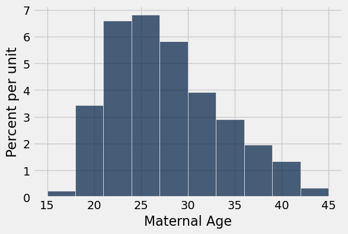

```python
births.select('Maternal Age').hist()
```

Compute the mean age of mothers in the sample.

```python
np.mean(births.column('Maternal Age'))
```

```
27.228279386712096
```

**Question**: What is the mean age of the mothers in *the population*?

Define a function to create one bootstrap resample and calculate the mean age for that resample.

```python
def one_bootstrap_mean():
    resample = births.sample()
    return np.mean(resample.column('Maternal Age'))
```

Generate means from 3000 bootstrap samples

```python
num_repetitions = 3000
bstrap_means = make_array()
for _ in np.arange(num_repetitions):
    bstrap_means = np.append(bstrap_means, one_bootstrap_mean())
```

Get the endpoints of the 95% confidence interval

```python
left = percentile(2.5, bstrap_means)
right = percentile(100-2.5, bstrap_means)

make_array(left, right)
```

```
array([ 26.89863714,  27.56643952])
```

Visualize the distribution of the bootstrap sample means.

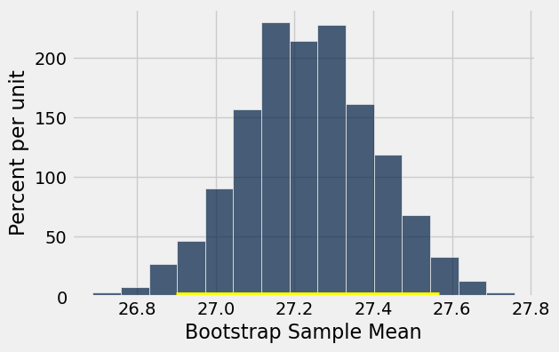

```python
resampled_means = Table().with_columns(
    'Bootstrap Sample Mean', bstrap_means
)
resampled_means.hist(bins=15)
plots.plot([left, right], [0, 0], color='yellow', lw=8);
```

### Can You Use a CI Like This?

By our calculation, an approximate 95% confidence interval for the average age of the mothers in the population is (26.9, 27.6) years.

True or False: About 95% of the mothers in the population were between 26.9 years and 27.6 years old.

Answer: ~False. We are analyzing the MEAN of 1174 mother's ages, not the actual ages.

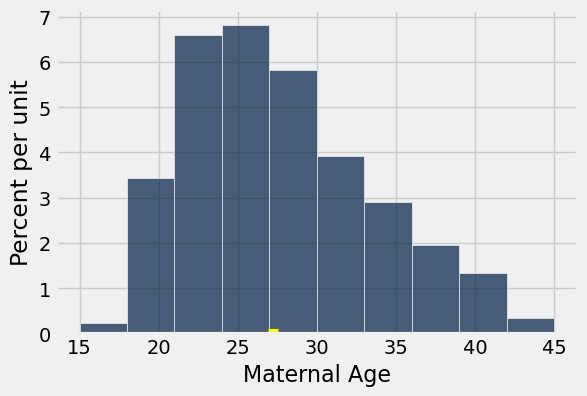

```python
births.hist('Maternal Age')
plots.plot([left, right], [0, 0], color='yellow', lw=8);
```

### Is This What a CI Means?

An approximate 95% confidence interval for the average age of the mothers in the population is (26.9, 27.6) years.

True or False: There is a 0.95 probability that the average age of mothers in the population is in the range 26.9 to 27.6 years.

Answer: False. The parameter is fixed and the interval is fixed.

### 95% Confidence

- Interval of estimates of a parameter
- Based on random sampling
- The process results in a random interval
- A "good" interval is one that contains the parameter
- The confidence is in the process that creates the interval: It generates a "good" interval with chance 95%

## Confidence Intervals For Testing

### Using a CI for Testing

- Null hypothesis: $\text{Population mean} = x$
- Alternative hypothesis: $\text{Population mean} \neq x$
- Cutoff for p-value: p%
- Method:
  - Construct a (100-p)% confidence interval for the population mean
  - Make a decision:
    - If x is not in the interval, reject the null
    - If x is in the interval, can't reject the null

### Using the Confidence Interval for Testing Hypotheses

**Null:** The mean age of mothers in the population is 25 years; the random sample average is different due to chance.

**Alternative:** The mean age of the mothers in the population is not 25 years.

Suppose you use the 5% cutoff for the p-value.

Based on the confidence interval, which hypothesis would you pick?

Answer: Since 25 is not in the 95% confidence interval (26.9, 27.6), then we have significant evidence to reject the null hypothesis.